# Gutkowski Shen Forecast Competition Submission

2026-04-24

# 1. Introduction

The objective of this project is to forecast daily electrical load using historical load data and meteorological variables. Multiple time series models were evaluated, including seasonal decomposition methods, ARIMA-based models, neural networks, and models incorporating exogenous weather variables. Model performance was assessed using RMSE and Kaggle competition scores. Top performing models included solo and combinations of TBATS and Neural Network models.

# 2. Data Import and Wrangling

```r
library(forecast)
library(lubridate)
library(ggplot2)
library(tidyverse)
library(readxl)
library(dplyr)
library(kableExtra)

### Load and process raw data

load_raw <- read_xlsx("./Data/Raw/load.xlsx")
humid_raw <- read_xlsx("./Data/Raw/relative_humidity.xlsx")
temp_raw <- read_xlsx("./Data/Raw/temperature.xlsx")

# Process load data
load_proc <- load_raw %>%
  mutate(daily_ave = rowMeans(load_raw[,3:26], na.rm = TRUE)) %>%
  select(date, daily_ave)

# Process humidity
humid_proc <- humid_raw %>%
  group_by(date) %>%
  summarise(across(3:26, ~ mean(.x, na.rm = TRUE)))

# Process temperature
temp_proc <- temp_raw %>%
  group_by(date) %>%
  summarise(across(3:26, ~ mean(.x, na.rm = TRUE)))

# daily mean temperature
temp_daily <- temp_proc %>%
  mutate(daily_temp = rowMeans(across(-date), na.rm = TRUE)) %>%
  select(date, daily_temp)

n_for <- 31
full_len <- nrow(load_proc)

# Align temperature with load training
train_temp <- temp_daily$daily_temp[1:(full_len - n_for)]
test_temp  <- temp_daily$daily_temp[(full_len - n_for + 1):full_len]

# Create time series
full_load_ts <- msts(load_proc$daily_ave,
                     seasonal.periods = c(7, 365.25),
                     start=c(2005,1,1))


train_data <- load_proc[1:(full_len - n_for), ]
test_data  <- load_proc[(full_len - n_for + 1):full_len, ]

train_load_ts <- msts(train_data$daily_ave,
                      seasonal.periods = c(7, 365.25),
                      start = c(2005,1,1))

test_load_ts <- msts(test_data$daily_ave,
                     seasonal.periods = c(7, 365.25),
                     start = end(train_load_ts) + c(0,1))


# Training Fourier terms
fourier_train <- fourier(train_load_ts, K = c(2,12))

# Test Fourier terms
fourier_test <- fourier(train_load_ts, K = c(2,12), h = n_for)



# Fourier terms + temperature
train_xreg <- cbind(fourier_train, temp = train_temp)
test_xreg  <- cbind(fourier_test,  temp = test_temp)
```

# 3. Models

## 1st in Kaggle: TBATS + Neural Network Combination (90/10 Weighting) - Score: 0.1019

After observing decent performance in TBATS and Neural Network models, weighted averages of these models were tested. The 90-10 TBATS-NN model was our top performing Kaggle model.

```r
TBATS_NN_9010 <- 0.9 * TBATS_for$mean + 0.1 * NN_for$mean

TBATS_NN_9010_ts <- ts(
  TBATS_NN_9010,
  start = start(test_load_ts),
  frequency = frequency(test_load_ts)
)
```

## 2nd in Kaggle: Solo TBATS Model - Score: 0.1023

The TBATS model was our second top performing model in Kaggle. All parameters were left as defaults for this model.

```r
TBATS_fit <- tbats(train_load_ts)
TBATS_for <- forecast(TBATS_fit, h=31)
```

## 3rd in Kaggle: TBATS + NN Combination (60/40 weighting) - Score: 0.1043

The 60-40 weighted TBATS-NN model was our third ranked Kaggle model.

```r
#averaging of functions (60/40 split)
TBATS_NN_6040 <- 0.6 * TBATS_for$mean + 0.4 * NN_for$mean

TBATS_NN_6040_ts <- ts(
  TBATS_NN_6040,
  start = start(test_load_ts),
  frequency = frequency(test_load_ts)
)
```

## 4th in Kaggle: TBATS + NN Combination (50/50 weighting) - Score: 0.1043

The 50-50 weighted TBATS-NN model was our fourth ranked Kaggle model.

```r
TBATS_NN_5050 <- 0.5 * TBATS_for$mean + 0.5 * NN_for$mean

TBATS_NN_5050_ts <- ts(
  TBATS_NN_5050,
  start = start(test_load_ts),
  frequency = frequency(test_load_ts)
)
```

## 5th in Kaggle: Neural Network + Fourier + Temperature - Score: 0.1214

The neural network model with Fourier terms and temperature as external regressors was included to attempt to account for both seasonal patterns and weather related influences on load.

```r
NN_T_fit <- nnetar(train_load_ts, p = 1, P = 0, xreg = train_xreg)

NN_T_for <- forecast(NN_T_fit, h = n_for, xreg = test_xreg)
```

# 4. Model Comparison

```r
TBATS_NN_9010_score <- accuracy(TBATS_NN_9010_ts, test_load_ts)
TBATS_scores <- accuracy(TBATS_for$mean, test_load_ts)
TBATS_NN_6040_score <- accuracy(TBATS_NN_6040_ts, test_load_ts)
TBATS_NN_5050_score <- accuracy(TBATS_NN_5050_ts, test_load_ts)
NN_T_scores <- accuracy(NN_T_for$mean, test_load_ts)

scores <- as.data.frame(
  rbind(TBATS_NN_9010_score, TBATS_scores, TBATS_NN_6040_score, TBATS_NN_5050_score, NN_T_scores)
)

row.names(scores) <- c("TBATS+NN (90/10)","TBATS","TBATS+NN (60/40)","TBATS+NN (50/50)","NN+Four+Temp")

kbl(scores, caption = "Forecast Accuracy for Load") %>%
  kable_styling(full_width = FALSE)
```

Forecast Accuracy for Load

|  | ME | RMSE | MAE | MPE | MAPE | ACF1 | Theil’s U |
| --- | --- | --- | --- | --- | --- | --- | --- |
| TBATS+NN (90/10) | 43.32130 | 402.0338 | 338.1646 | 0.1810772 | 9.037366 | 0.6165721 | 1.2253800 |
| TBATS | 45.70463 | 417.4762 | 349.6332 | 0.2120964 | 9.342013 | 0.6403287 | 1.2750198 |
| TBATS+NN (60/40) | 36.17131 | 365.4995 | 306.0089 | 0.0880196 | 8.186078 | 0.5434124 | 1.1078795 |
| TBATS+NN (50/50) | 33.78798 | 357.1425 | 295.8616 | 0.0570003 | 7.917831 | 0.5213366 | 1.0810846 |
| NN+Four+Temp | -21.37425 | 241.5962 | 196.5076 | -0.7990296 | 5.303150 | 0.5131940 | 0.7493435 |

By RMSE, the neural network model with Fourier terms and temperature as external regressors was the top performing model. However, in Kaggle, this model ranked fifth. While the 90/10 weighted TBATS-NN model ranked second to last in our forecast accuracy tests, it was the top performing model in Kaggle. This suggests that lower RMSE on the test set did not necessarily translate to better performance on the Kaggle evaluation.

# 5. Forecast Comparison Plot

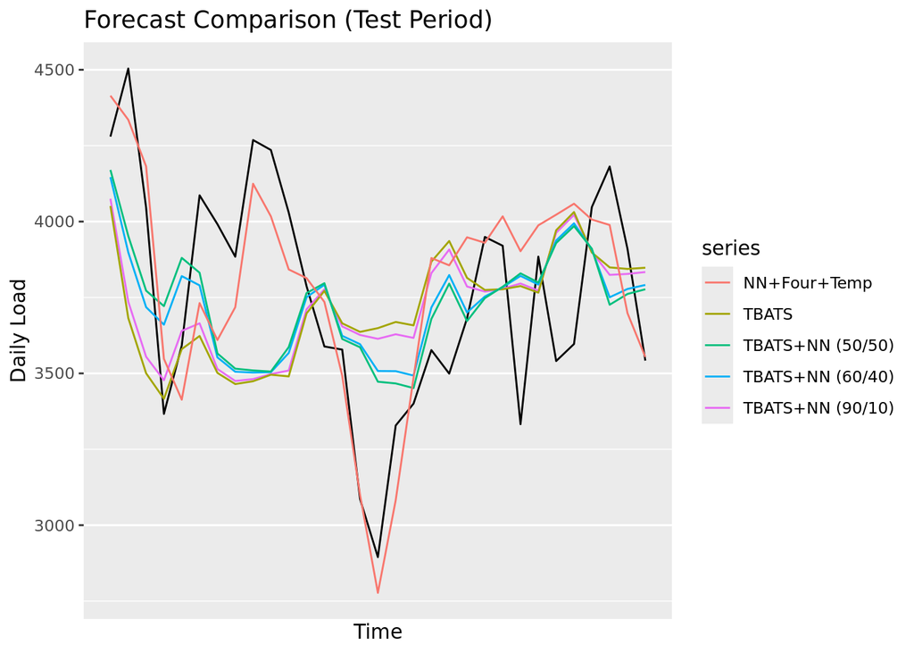

```r
autoplot(test_load_ts) +
  autolayer(TBATS_NN_9010_ts, series="TBATS+NN (90/10)") +
  autolayer(TBATS_for$mean, series="TBATS") +
  autolayer(TBATS_NN_6040_ts, series="TBATS+NN (60/40)")+
  autolayer(TBATS_NN_5050_ts, series="TBATS+NN (50/50)") +
  autolayer(NN_T_for$mean, series = "NN+Four+Temp")+
  ylab("Daily Load") +
  ggtitle("Forecast Comparison (Test Period)")
```

# 6. Results and Discussion

The results indicate that seasonal structure is the dominant driver of electrical load. In the Kaggle competition, the 90/10 weighted TBATS–Neural Network model outperformed all other models, showing that combining models can improve forecasting performance.

While the neural network model with Fourier terms and temperature performed best based on RMSE, it did not translate to strong Kaggle performance. This suggests that incorporating weather variables does not necessarily improve forecasts compared to models that more effectively capture complex seasonal patterns, such as the TBATS+NN combinations.

# 7. Git-Hub Link

https://github.com/shens2746-tech/Gutkowski_Shen_ENV797_TSA_ForecastCompetition_S26.git

# 8. AI Statement

AI tools were used to assist with debugging code and providing ideas for model implementation. All modeling decisions and interpretations were checked by group members.